# Exploring the R Bugzilla

# Closing bug reports

As seen closing issues might have some effect on users. Issues might get closed for a variety of reasons as we have seen, but maybe there is some hint to something bugRzilla could help:

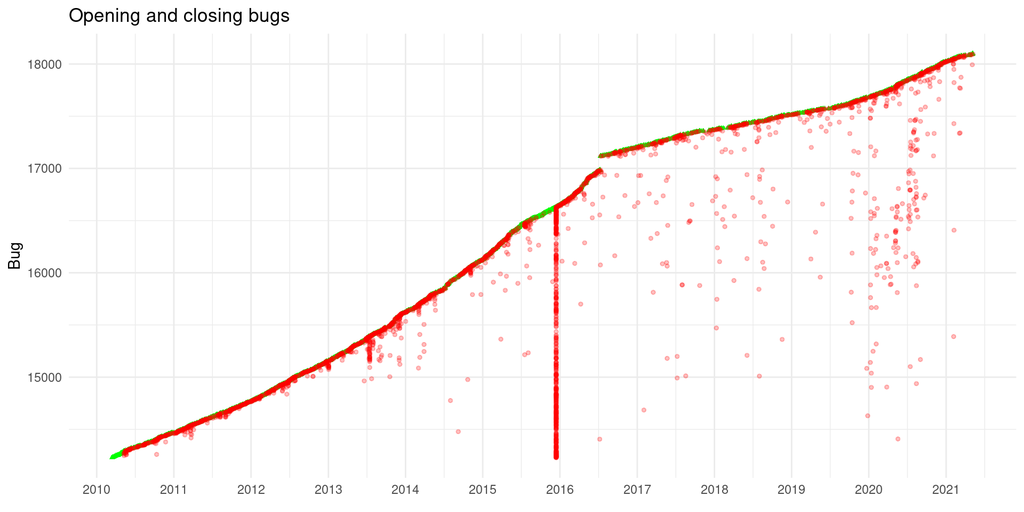

```r
closing_time <- db_activity_bugs |>
  group_by(bug_id) |>
  summarize(
    creation_t = unique(creation_ts),
    closed_t = max(bug_when[added == "CLOSED"])) |>
  ungroup() |>
  mutate(diff_t = difftime(closed_t, creation_t, units = "hours")) |>
  mutate(diff_t = if_else(closed_t < as.difftime(0, units = "hours") | is.na(closed_t), as.difftime("NA", units = "hours"), diff_t)) |>
  mutate(closed = !is.na(diff_t == 0))

ggplot(closing_time) +
  geom_point(aes(x = creation_t, y = bug_id), col = "green", shape = 17, size = 1) +
  geom_point(aes(x = closed_t, y = bug_id), col = "red", size = 1, data = function(x){ filter(x, closed)}, alpha = 0.25) +
  scale_x_datetime(date_breaks = "1 year", date_labels = "%Y") +
  labs(x = element_blank(), y = "Bug", title = "Opening and closing bugs")
```

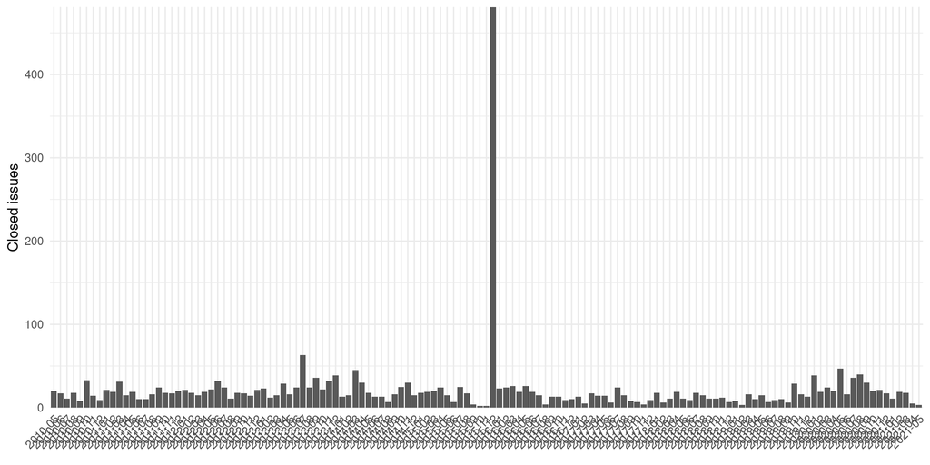

```r
closing_time |>
  filter(closed) |>
  group_by(month = format(closed_t, "%Y-%m")) |>
  count() |>
  ggplot() +
  geom_col(aes(x = month, y = n)) +
  theme(axis.text.x = element_text(angle = 45, hjust = 1)) +
  scale_y_continuous(expand = expansion()) +
  labs(x = element_blank(), y = "Closed issues")
```

The big spike of near 500 closed issues on 2015-12 (presumably automatic), distorts a bit the graphic.

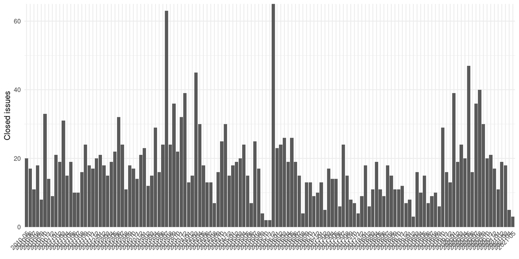

```r
closing_time |>
  filter(closed) |>
  group_by(month = format(closed_t, "%Y-%m")) |>
  count() |>
  ggplot() +
  geom_col(aes(x = month, y = n)) +
  theme(axis.text.x = element_text(angle = 45, hjust = 1, vjust = 1)) +
  coord_cartesian(ylim = c(0, 65)) +
  scale_y_continuous(expand = expansion()) +
  labs(x = element_blank(), y = "Closed issues")
```

With near to 20 bugs closed each month, the question is which ones are closed faster? Perhaps some kind of resolution or status of bugs are closed sooner?

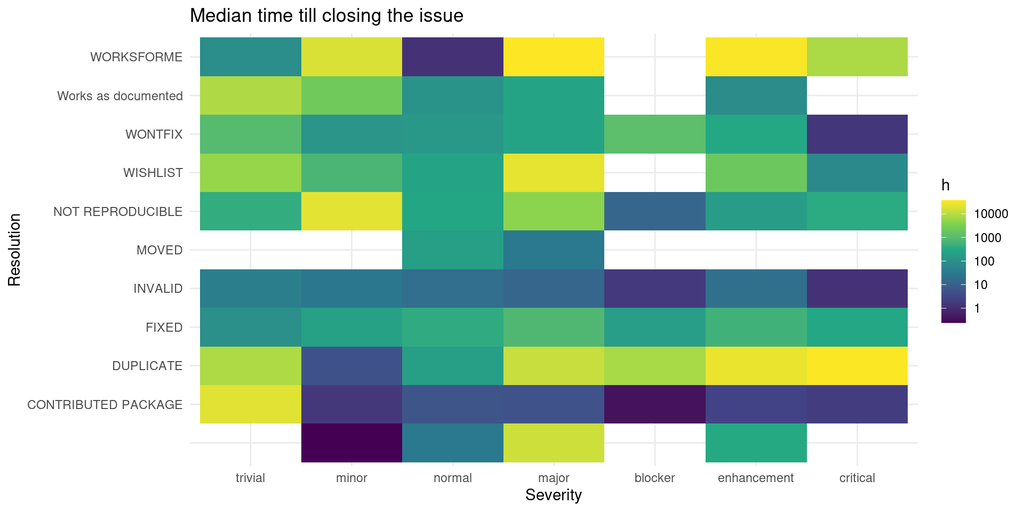

```r
db_bugs4 |>
  merge(closing_time, by = "bug_id", all.x = TRUE, all.y = FALSE) |>
  filter(closed) |>
  group_by(resolution, bug_severity) |>
  summarize(f = as.numeric(median(diff_t))) |>
  ungroup() |>
  ggplot() +
  geom_tile(aes(bug_severity, resolution, fill = f)) +
  scale_fill_viridis_c(trans = "log10") +
  labs(x = "Severity", y = "Resolution", fill = "h",
       title = "Median time till closing the issue")
## `summarise()` has grouped output by 'resolution'. You can override using the `.groups` argument.
```

Usually it takes some time to close a bug report as duplicate. Maybe this is because one needs some familiarity with the previous reported bugs.

Which bugs are harder to close or need more information?

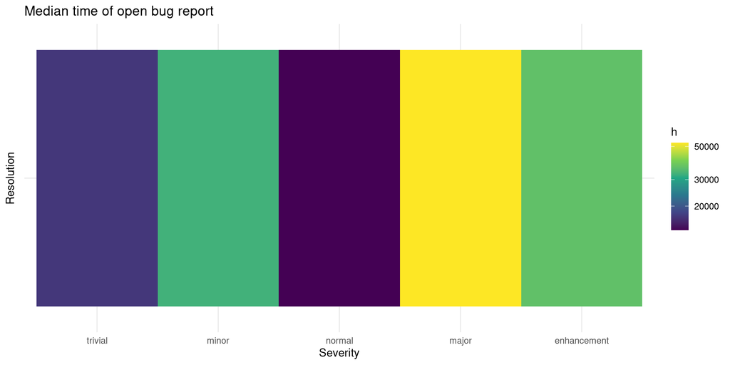

```r
db_bugs4 |>
  merge(closing_time, by = "bug_id", all.x = TRUE, all.y = FALSE) |>
  filter(!closed) |>
  mutate(ct = difftime(as.Date("2021/03/25"), creation_t, units = "hours")) |>
  group_by(resolution, bug_severity) |>
  summarize(f = as.numeric(median(ct)), n = n()) |>
  ungroup() |>
  filter(n > 5) |>
  ggplot() +
  geom_tile(aes(bug_severity, resolution, fill = f)) +
  scale_fill_viridis_c(trans = "log10") +
  labs(x = "Severity", y = "Resolution", fill = "h",
       title = "Median time of open bug report")
## `summarise()` has grouped output by 'resolution'. You can override using the `.groups` argument.
```

Bugs without resolution described as major are more time open, presumably because they take more time to fix too. Next are enhancements, which makes sense that enhancements take some time till they are incorporated to R source code. Perhaps is the effect of the recent call to help on Bugzilla but the normal bug reports seem to be the ones less time open.

# Conclusion

There is room for improvements on the bug reporting process from users:

- Include some efforts to trace the origin of the bug report.
- Include a patch whenever possible or some suggestions how you think the bug could be fixed.
- Give details of the kind of the bug or at least not always using the default options of the tracker.

Also some advice to bug reporters:

- Don’t expect a fast comment if the issue is complicated.
[^1]: If you explore the code, the warning tells us that there are some bugs without date of creation.
[^2]: Note that this is only based on Bugzilla, and activity on Jitterbug might have been different.